# Statistical Inference - Basic Inferential Data Analysis

H.Harvey

25 December 2015

## Introduction

The purpose of this project is to perform basic exploratory and inferential data analysis using the ToothGrowth data in the R datasets package.

## Setting the environment

```r
library(dplyr)
```

```r
library(ggplot2)
data(ToothGrowth)
```

## Data structure:

A data frame with 60 observations on 3 variables. “len” numeric Tooth length / “supp” factor Supplement type (VC-Vitamin C or OJ-Orange Juice) / “dose” numeric Dose in milligrams/day (0.5 / 1.0 / 2.0)

## Initial data exploration

```r
# Looking at the dataset
str(ToothGrowth)
```

```
## 'data.frame':    60 obs. of  3 variables:
##  $ len : num  4.2 11.5 7.3 5.8 6.4 10 11.2 11.2 5.2 7 ...
##  $ supp: Factor w/ 2 levels "OJ","VC": 2 2 2 2 2 2 2 2 2 2 ...
##  $ dose: num  0.5 0.5 0.5 0.5 0.5 0.5 0.5 0.5 0.5 0.5 ...
```

```r
# Validating the structure
head(ToothGrowth)
```

```
##    len supp dose
## 1  4.2   VC  0.5
## 2 11.5   VC  0.5
## 3  7.3   VC  0.5
## 4  5.8   VC  0.5
## 5  6.4   VC  0.5
## 6 10.0   VC  0.5
```

```r
#  Validating the number of rows
nrow(ToothGrowth)
```

```
## [1] 60
```

```r
# Getting a statistical summary of the variables
summary(ToothGrowth)
```

```
##       len        supp         dose
##  Min.   : 4.20   OJ:30   Min.   :0.500
##  1st Qu.:13.07   VC:30   1st Qu.:0.500
##  Median :19.25           Median :1.000
##  Mean   :18.81           Mean   :1.167
##  3rd Qu.:25.27           3rd Qu.:2.000
##  Max.   :33.90           Max.   :2.000
```

```r
# Checking that no missing data exist
sum(is.na(ToothGrowth))
```

```
## [1] 0
```

```r
# Representing the numbers of case per dose & supplement type to validation # the distribution of cases.
table(ToothGrowth$supp,ToothGrowth$dose)
```

```
##
##      0.5  1  2
##   OJ  10 10 10
##   VC  10 10 10
```

The dataset is split equally within the supplement type (30 observations each) and dose (10 observations each). For each supplement type, and a given dose, 10 subjects received Orange Juice and another received Vitamin C.

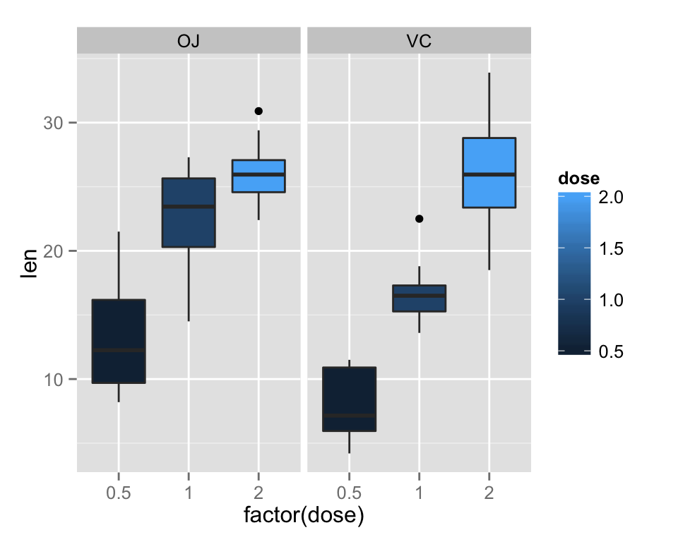

```r
q <- ggplot(ToothGrowth,aes(factor(dose),len)) +
      geom_boxplot(aes(fill=dose)) + facet_grid(.~supp)
print(q)
```

From the above graph, Orange Juice in doses of 0.5 and 1.0mg seems to support tooth growth over Vitamin C. However, at higher dosage (2.0mg), there doesn’t seems to be one supplement better than the other.

## Hypotheses

**Null Hypothesis (H0):** Orange Juice and Vitamin C have the same effect on tooth growth.

**Alternative Hypothesis (Ha):** Orange Juice and Vitamin C do not have the same effect on tooth growth.

A p-value of 0.05 or 5% was used to determine whether the null hypothesis (H0) is rejected or not. If p<0.05, the (H0) was rejected.

## Data preparation

```r
# Calculating the mean by supplement type and doses for t.test reference
stats_df <-ToothGrowth %>%
      group_by(supp,dose) %>%
      summarise(mean_Len = mean(len), stddev_Len = sd(len), n = n())
# Calculating the mean by dose
stats_df %>% group_by(dose) %>% summarise(mean_d=mean(mean_Len))
```

```
## Source: local data frame [3 x 2]
##
##   dose mean_d
## 1  0.5 10.605
## 2  1.0 19.735
## 3  2.0 26.100
```

```r
# Calculating the mean by supplement type
stats_df %>% group_by(supp) %>% summarise(mean_d=mean(mean_Len))
```

```
## Source: local data frame [2 x 2]
##
##   supp   mean_d
## 1   OJ 20.66333
## 2   VC 16.96333
```

## Hypotheses calculation

```r
# t.test of by dose & supplement type
t_d0 <- ToothGrowth %>% filter(dose == 0.5)
t_d1 <- ToothGrowth %>% filter(dose == 1)
t_d2 <- ToothGrowth %>% filter(dose == 2)

# Assessing Orange Juice over Vitamin C (variable order)
t.test(filter(t_d0,supp=="OJ")$len,filter(t_d0,supp=="VC")$len ,paired = FALSE, var.equal = TRUE)
```

```
##
##  Two Sample t-test
##
## data:  filter(t_d0, supp == "OJ")$len and filter(t_d0, supp == "VC")$len
## t = 3.1697, df = 18, p-value = 0.005304
## alternative hypothesis: true difference in means is not equal to 0
## 95 percent confidence interval:
##  1.770262 8.729738
## sample estimates:
## mean of x mean of y
##     13.23      7.98
```

```r
t.test(filter(t_d1,supp=="OJ")$len,filter(t_d1,supp=="VC")$len ,paired = FALSE, var.equal = TRUE)
```

```
##
##  Two Sample t-test
##
## data:  filter(t_d1, supp == "OJ")$len and filter(t_d1, supp == "VC")$len
## t = 4.0328, df = 18, p-value = 0.0007807
## alternative hypothesis: true difference in means is not equal to 0
## 95 percent confidence interval:
##  2.840692 9.019308
## sample estimates:
## mean of x mean of y
##     22.70     16.77
```

```r
t.test(filter(t_d2,supp=="OJ")$len,filter(t_d2,supp=="VC")$len ,paired = FALSE, var.equal = TRUE)
```

```
##
##  Two Sample t-test
##
## data:  filter(t_d2, supp == "OJ")$len and filter(t_d2, supp == "VC")$len
## t = -0.046136, df = 18, p-value = 0.9637
## alternative hypothesis: true difference in means is not equal to 0
## 95 percent confidence interval:
##  -3.722999  3.562999
## sample estimates:
## mean of x mean of y
##     26.06     26.14
```

Orange Juice vs Vitamin C:

- dose: 0.5 -> lwr(1.770) upper(8.730) p-value(0.00530)
- dose: 1.0 -> lwr(2.841) upper(9.019) p-value(0.0008)
- dose: 2.0 -> lwr(-3.723) upper(3.563) p-value(0.964)

The p-value of the 0.5 and 1.0 dosages demonstrate that there is a difference in the tooth growth for each supplement type. However, at 2.0mg dosage,the p-value doesn’t allow one to claim that a differene exist, or is not due to chance.

The confidence interval of the 0.5 and 1.0 dosages indicate that the Orange Juice supplement is more effective than the Vitamin C (positive interval). However, at higher dosage (2.0mg), the effect between supplement type seems to be equivalent due to the symmetrical value of the interval.

## Conclusion

The results of both the null hypothesis tests and confidence intervals demonstrate that doses of 0.5 and 1.0mg of Orange Juice is more effective in tooth growth. However, at higher dosage,2.0mg, neither supplement type is more effective.

Finally, it can be concluded that tooth growth increase with doses.